# lecture-02-research-process

## M303 Marketing Research

[figure not shown]

LECTURE 02 · FALL 2026

M303

Marketing Research Process

From a managerial problem to research questions, hypotheses, and better decisions.

## Where we are

**FROM DEFINITION TO PROCESS**Lecture 1 established why marketing research matters; today we translate a managerial concern into an actionable research plan.

01**Name tags**

Please keep using them while I learn everyone’s name.

02**Devices**

Keep phones, tablets, and laptops away unless we are using them for class.

03**Project groups**

Finalize your group members.

04**Schedule conflicts**

Contact me as early as possible.

## Learning Objectives

01

**Understand the preliminary stages**

Move from a problem or opportunity to actionable research objectives, questions, and hypotheses.

02

**Calculate the value of information**

Use illustrative decision trees to compare alternatives under uncertainty.

## Prior-class review

Business intelligence bridges business users and information from different data sources.

**TRUE**

Marketing research links the firm and the market through information.

**TRUE**

Marketing intelligence acquires and analyzes marketing data to improve decisions.

**TRUE**

Marketing research is a potential waste of resources; managers should rely on educated guesses instead.

**FALSE**

## Course roadmap

Problem formulationResearch designData collectionData analysis & recommendations

PRELIMINARY STAGES

**Define the decision before designing the study.**

Each step narrows a broad concern into information that can support action.

01

What is the problem or opportunity?

02

What is the actionable management problem?

03

What should the research achieve? **Define research objectives.**

04

What should the research answer? **Define research questions.**

05

What are the possible answers? **Define hypotheses.**

06

How will the information change the decision?

07

Compare the value of information with the cost of the research.

## From a product problem to testable hypotheses

VIZIO MODEL XYZ · 4K TV

**Problem: low sales attributed to inferior quality.**

Move from the problem to actionable decisions, information needs, and possible answers.

### What is the problem?

Low sales of Vizio Model XYZ 4K TV due to its inferior quality.

### What is the actionable management problem?

Which attributes should be improved—screen, sound, color clarity, refresh rate, processor, price, or something else?

### What should the research achieve? Define research objectives.

- Determine which attributes consumers care about most.
- Determine consumers’ additional willingness to pay for each upgrade in quality.
- Determine the cost of upgrading each attribute.

### What should the research answer? Define research questions.

- Which product attributes increase perceived quality the most?
- How much additional willingness to pay do consumers have for each upgraded product attribute?
- What is the cost of increasing the quality of each attribute?

### What are the possible answers? Define hypotheses.

- Consumers care most about screen quality.
- Consumers are willing to pay up to $100 more for a better refresh rate.

## What is a problem—or an opportunity?

PROBLEM

**A gap between what you expected and what occurred.**

A problem may also reveal an opportunity. Lower candy consumption, for example, is a threat to an existing product and an opportunity for a healthier alternative.

◎

> “The formulation of the problem is often more essential than its solution.”

Albert Einstein

## Symptoms are visible; causes sit below the surface

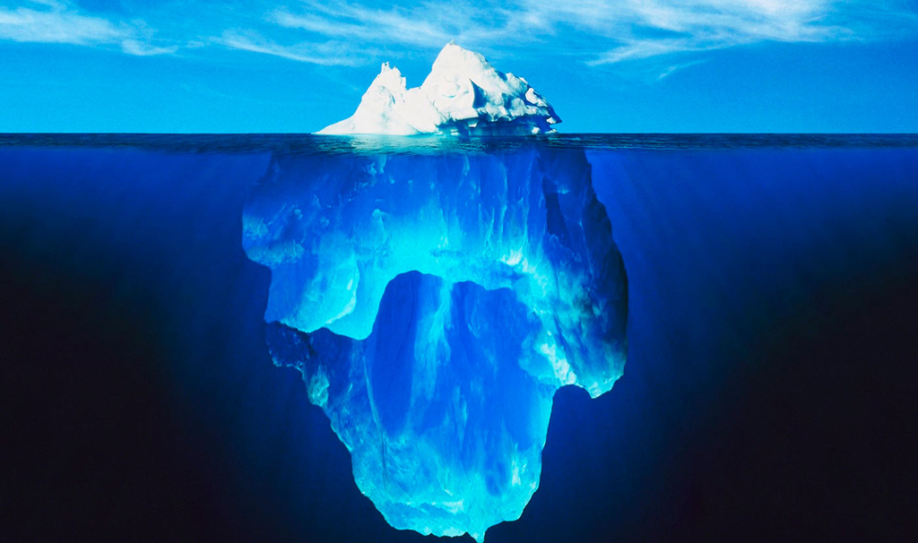

**10–20%**of an iceberg is visible above the water

SYMPTOM

**Sales declined by 15%.**

01

Perceptions of inferior product quality

02

Poor brand image

03

Unsatisfactory customer service

04

A price that is too high for the benefits received

## Link research to an actionable decision

BACKWARD MARKETING RESEARCH

**Begin at the end.**

If the research cannot change a feasible decision, it does not create managerial value.

Backward Marketing Research · *Harvard Business Review* · 1985

01

Determine how the research results will be used.

02

Determine what the final report should contain.

03

Specify the analyses needed to produce those results.

04

Determine what kind of data those analyses require.

## What are research objectives?

RESEARCH OBJECTIVES

**Statements of the information needed to solve the marketing problem.**

Frame the objectives so that the information obtained can address the actionable management problem.

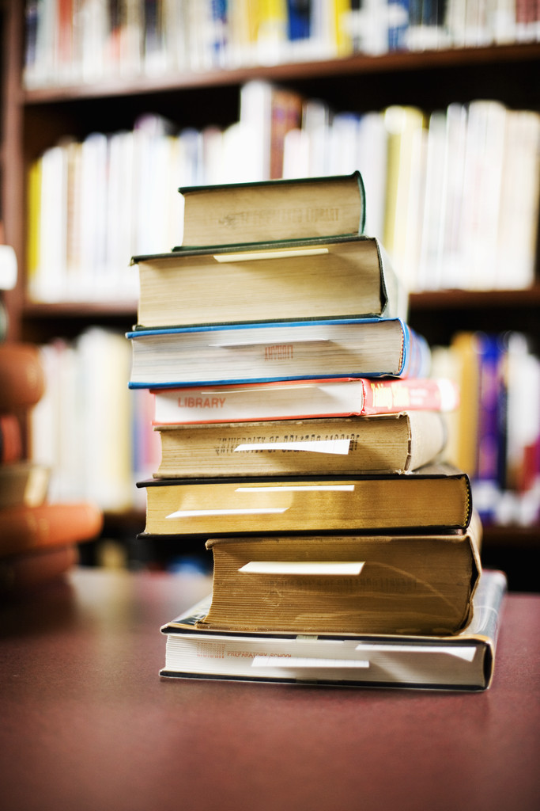

## What are research questions?

RESEARCH QUESTIONS

**Specific questions the study must answer to achieve its objectives.**

For an advertisement decision, ask:

- Will the advertisement be noticed?
- Will it be interpreted accurately?
- Will it influence consumers’ behavior?

RESEARCH OBJECTIVE

narrows into

Will it be noticed?

Will it be understood?

Will it change behavior?

## What are hypotheses?

HYPOTHESIS

**A possible answer to a research question.**

A useful hypothesis makes information needs more specific and testable.

01**Prior research**

Draw on previous research efforts, including exploratory research.

02**Relevant disciplines**

Borrow from psychology, sociology, marketing, and economics.

03**Managerial experience**

Combine experience with related problems, situation analysis, knowledge, and judgment.

## BagNV: a promising idea with a decision problem

[figure not shown]

AMERICA’S MOST PROMISING STARTUPS

**Success Isn’t in the Bag Yet**

Emily Schmitt · July 21, 2009

[figure not shown]

BagNV founder Tamika Powell (right) and sales vice president Johanna Rodriguez

Women love purses, and many love low-stakes gambling, too. Put the passions together via a monthly raffle for designer handbags, and Tamika Powell figured she would have a business—one day, perhaps. But her idea had not caught on yet.

Powell, 30, launched [BagNV.net](http://www.bagnv.net/) in February, a year after she was laid off as a human-resources consultant. She sold raffle tickets at $2 apiece, payable through PayPal, for a chance to win a high-end bag retailing for $300 to $500. With shoppers turning frugal, she thought her timing was nearly perfect: “We’re trying to be an answer to the recession.” Prizes had included a Puma Remix grip bag and a Coach Sabrina Op Art handbag.

At the time of the article, Powell—who lived in North Hollywood, California—had spent more than $1,200 on purses, shipping, and overhead but had brought in only $100. She said she might raise ticket prices on more expensive bags and could not rely only on word-of-mouth marketing. One option was sponsoring a fashion show.

## BagNV: translate the concern into research

### Problems

Few customers ← low awareness

Low sales and revenues

### Actionable management problem

How should the advertising budget be allocated across media channels to increase awareness and sales?

### Research objectives

Determine the target group.

Determine which types of media are effective for the target group.

Estimate the awareness generated by each type of media and channel.

Estimate the cost of each medium and channel.

### Research questions

Who are my customers?

What are their characteristics?

Which channels are most appealing to my customers?

How much attention do they pay to advertising in these media?

What are the costs of the different media channels?

### Hypotheses

Social media will be less effective than television advertising.

Local radio will be the most cost-efficient channel for increasing awareness.

## Local bank: weekend operations

PROBLEMS

**Decreased profits****Higher employee costs on Saturdays**

### Actionable management problem

Decide whether to keep branches open on Saturday.

### Research objectives

Evaluate the use of services on Saturday.

Determine whether customers’ needs can be met on weekdays.

### Research questions

What is the usage rate on Saturdays?

What types of customers use the service?

What alternatives would appeal to them?

### Hypotheses

The usage rate on Saturdays is less than half the weekday usage rate.

Higher-income customers are more likely to use weekend service.

## Estimate the value of information before collecting it

01**Importance**

How consequential is the decision?

02**Uncertainty**

How uncertain are the outcomes?

03**Influence**

Could the research change the decision?

EXPECTED VALUE**Better decision**

How much can the information improve the expected outcome?

>

RESEARCH COST**Time + money**

What must the organization spend to obtain the information?

Conduct the research when its expected value exceeds its cost.

## Use illustrative decision models

CASE A

**Introduce**0.6 Success → **$4M**0.4 Failure → **$1M**

**Do not introduce****$0**

CASE B

**Introduce**0.6 Success → **$1M**0.4 Failure → **−$2M**

**Do not introduce****$0**

CASE B · EXPECTED RETURN FROM INTRODUCTION

**0.6($1M) + 0.4(−$2M) = −$0.2M**

Based on expected return alone, do not introduce Case B.

## In-class exercise 1: direct mail

VICTORIA’S SECRET

**Should the company launch a direct-mail campaign?**

1,000,000 potential customers · $2 mailing cost per person · $100 profit per converted customer

### With direct mail

The conversion rate is uncertain:

**60% chance → 3%****40% chance → 1%**

### Without direct mail

Expected purchase rate:

**0.5%**

$100 profit per customer

Which option has the higher expected profit: **A. no direct mail** or **B. direct mail**?

## In-class exercise 1: solution

A

Expected profit without direct mail

**1M × 0.5% × $100 = $0.5M**

NO DIRECT MAIL**$0.5M**

B1

Expected conversion rate

**0.6(3%) + 0.4(1%) = 2.2%**

B2

Expected direct-mail revenue

**1M × 2.2% × $100 = $2.2M**

B3

Direct-mail cost

**1M × $2 = $2.0M**

B4

Expected profit with direct mail

**$2.2M − $2.0M = $0.2M**

DIRECT MAIL**$0.2M · choose A**

## In-class exercise 2

Choose a firm and identify a marketing research problem or opportunity that interests you.

01

State the problem or opportunity.

02

State research objectives and questions.

03

State your hypotheses.

## To sum up

01

Define the problem or opportunity.

02

Identify the actionable management problem.

03

Specify research objectives.

04

Write research questions.

05

State hypotheses.

BEFORE CONDUCTING THE STUDY

**Use decision-tree analysis to calculate the value of the research.**

Compare the expected value of the information with the cost of obtaining it.

## Next class

COMING NEXT

Research Design  
and Implementation

Choose the research design, data sources, and sampling approach that fit the decision.

**Problem formulation**Preliminary stages**Research design**Decide on the type of research**Data collection**Secondary data · Primary data · Sampling**Data analysis & recommendations**Preparation · Descriptive analysis · Hypothesis testing · Correlation and regression